# Conceitos estatisticos para IA

```r
library(corrplot)
library(corrgram)
library(skimr)
library(knitr)
library(ggplot2)
library(dplyr)
library(formattable)
library(randomForest)
library(caret)
library(readr)
library(gmodels)
library(outliers)
```

# 1 Introdução

Esta análise aplica-se a um dataset de variantes do vinho portugues “Vinho Verde”, possuindo diversos indicadores de suas caracteristicas, como acidez, teor alcoolico, quantidade de açucar, entre outros…

# 2 Carregando dados

```r
vinhos <- read.csv("BaseWine_Red_e_White.csv", header = TRUE, sep = ";", dec = ",")
```

# 3 Análise Exploratória dos Dados

## 3.1 Conhecendo as variaveis

### 3.1.1 Sumario da Base original

```r
summary(vinhos)
```

```
##     id_vinho     fixedacidity    volatileacidity    citricacid
##  Min.   :   1   Min.   : 3.800   Min.   :0.0800   Min.   :0.0000
##  1st Qu.:1625   1st Qu.: 6.400   1st Qu.:0.2300   1st Qu.:0.2500
##  Median :3249   Median : 7.000   Median :0.2900   Median :0.3100
##  Mean   :3249   Mean   : 7.215   Mean   :0.3397   Mean   :0.3186
##  3rd Qu.:4873   3rd Qu.: 7.700   3rd Qu.:0.4000   3rd Qu.:0.3900
##  Max.   :6497   Max.   :15.900   Max.   :1.5800   Max.   :1.6600
##  residualsugar     chlorides       freesulfurdioxide totalsulfurdioxide
##  Min.   : 0.60   Min.   :0.00900   Min.   :  1.00    Min.   :  6.0
##  1st Qu.: 1.80   1st Qu.:0.03800   1st Qu.: 17.00    1st Qu.: 77.0
##  Median : 3.00   Median :0.04700   Median : 29.00    Median :118.0
##  Mean   : 5.44   Mean   :0.05603   Mean   : 30.53    Mean   :115.7
##  3rd Qu.: 8.10   3rd Qu.:0.06500   3rd Qu.: 41.00    3rd Qu.:156.0
##  Max.   :45.80   Max.   :0.61100   Max.   :289.00    Max.   :440.0
##     density             pH          sulphates         alcohol
##  Min.   :0.9871   Min.   :2.720   Min.   :0.2200   Min.   : 0.9567
##  1st Qu.:0.9923   1st Qu.:3.110   1st Qu.:0.4300   1st Qu.: 9.5000
##  Median :0.9949   Median :3.210   Median :0.5100   Median :10.3000
##  Mean   :0.9947   Mean   :3.219   Mean   :0.5313   Mean   :10.4862
##  3rd Qu.:0.9970   3rd Qu.:3.320   3rd Qu.:0.6000   3rd Qu.:11.3000
##  Max.   :1.0140   Max.   :4.010   Max.   :2.0000   Max.   :14.9000
##     quality        Vinho
##  Min.   :3.000   RED  :1599
##  1st Qu.:5.000   WHITE:4898
##  Median :6.000
##  Mean   :5.818
##  3rd Qu.:6.000
##  Max.   :9.000
```

```r
str(vinhos)
```

```
## 'data.frame':    6497 obs. of  14 variables:
##  $ id_vinho          : int  1 2 3 4 5 6 7 8 9 10 ...
##  $ fixedacidity      : num  6.6 6.7 10.6 5.4 6.7 6.8 6.6 7.2 5.1 6.2 ...
##  $ volatileacidity   : num  0.24 0.34 0.31 0.18 0.3 0.5 0.61 0.66 0.26 0.22 ...
##  $ citricacid        : num  0.35 0.43 0.49 0.24 0.44 0.11 0 0.33 0.33 0.2 ...
##  $ residualsugar     : num  7.7 1.6 2.2 4.8 18.8 ...
##  $ chlorides         : num  0.031 0.041 0.063 0.041 0.057 0.075 0.069 0.068 0.027 0.035 ...
##  $ freesulfurdioxide : num  36 29 18 30 65 16 4 34 46 58 ...
##  $ totalsulfurdioxide: num  135 114 40 113 224 49 8 102 113 184 ...
##  $ density           : num  0.994 0.99 0.998 0.994 1 ...
##  $ pH                : num  3.19 3.23 3.14 3.42 3.11 3.36 3.33 3.27 3.35 3.11 ...
##  $ sulphates         : num  0.37 0.44 0.51 0.4 0.53 0.79 0.37 0.78 0.43 0.53 ...
##  $ alcohol           : num  10.5 12.6 9.8 9.4 9.1 9.5 10.4 12.8 11.4 9 ...
##  $ quality           : int  5 6 6 6 5 5 4 6 7 6 ...
##  $ Vinho             : Factor w/ 2 levels "RED","WHITE": 2 2 1 2 2 1 1 1 2 2 ...
```

Dataset com 13 variaveis, dentre elas a variável “quality” indica a qualidade medida de cada vinho.

- **fixedacidity:** Indica a quantidade de acidos presente no vinho (voláteis ou não voláteis);
- **volatileacidity:** Indica a quantidade de ácido acético no vinho, que em níveis muito altos pode levar a um gosto desagradável de vinagre;
- **citricacid:** Indica a quantidade de ácido cítrico, pode adicionar “frescura” e sabor aos vinhos;
- **residualsugar:** Indica a quantidade de açúcar restante depois que o processo de fermentação;
- **chlorides:** Indica a quantidade de sal no vinho;
- **freesulfurdioxide:** Indica a quantidade da forma livre de SO2, impede o crescimento microbiano e a oxidação do vinho, Garante condições melhores para os processos de vinificação da bebida, elimina bactérias e leveduras frágeis e indesejáveis, o que permite que apenas as melhores prossigam com o processo fermentativo. Além do mais, melhora o aroma e afina a cor da bebida;
- **totalsulfurdioxide:** Indica a quantidade de formas livres e encadernadas de S02; em baixas concentrações, o SO2 é quase indetectável no vinho, mas nas concentrações de SO2 livre acima de 50 ppm, o SO2 se torna evidente no nariz e no sabor do vinho;
- **density:**indica a densidade do vinho, a densidade é próxima à da água, dependendo do percentual de álcool e teor de açúcar;
- **pH:** descreve como o vinho é acídico ou básico numa escala de 0 (muito ácido) a 14 (muito básico); a maioria dos vinhos tem entre 3-4 na escala de pH;
- **sulphates:** Indica a quantidade de sulfatos, um aditivo de vinho que pode contribuir para os níveis de gás de dióxido de enxofre (S02), que age como um antimicrobiano e antioxidante;
- **alcohol:** Indica o teor alcoólico percentual do vinho;
- **quality:** variável de saída (com base em dados sensoriais) que poderiam ser de 0 a 10 sendo zero muito ruim e 10 muito excelente;
- **Vinho:** variável qualitativa nominal que indica se o vinho é tinto ou branco.

## 3.2 Verificação da completude da amostra

É importante averiguarmos a existẽncia de dados incompletos na amostra de modo que possam influenciar a análise e o desenvolvimento dos modelos estatísticos:

```r
skim(vinhos) %>% skimr::kable()
```

Skim summary statistics  
n obs: 6497  
n variables: 14

Variable type: factor

| variable | missing | complete | n | n_unique | top_counts | ordered |
| --- | --- | --- | --- | --- | --- | --- |
| Vinho | 0 | 6497 | 6497 | 2 | WHI: 4898, RED: 1599, NA: 0 | FALSE |

Variable type: integer

| variable | missing | complete | n | mean | sd | p0 | p25 | p50 | p75 | p100 | hist |
| --- | --- | --- | --- | --- | --- | --- | --- | --- | --- | --- | --- |
| id_vinho | 0 | 6497 | 6497 | 3249 | 1875.67 | 1 | 1625 | 3249 | 4873 | 6497 | ▇▇▇▇▇▇▇▇ |
| quality | 0 | 6497 | 6497 | 5.82 | 0.87 | 3 | 5 | 6 | 6 | 9 | ▁▁▆▇▁▃▁▁ |

Variable type: numeric

| variable | missing | complete | n | mean | sd | p0 | p25 | p50 | p75 | p100 | hist |
| --- | --- | --- | --- | --- | --- | --- | --- | --- | --- | --- | --- |
| alcohol | 0 | 6497 | 6497 | 10.49 | 1.22 | 0.96 | 9.5 | 10.3 | 11.3 | 14.9 | ▁▁▁▁▆▇▃▁ |
| chlorides | 0 | 6497 | 6497 | 0.056 | 0.035 | 0.009 | 0.038 | 0.047 | 0.065 | 0.61 | ▇▁▁▁▁▁▁▁ |
| citricacid | 0 | 6497 | 6497 | 0.32 | 0.15 | 0 | 0.25 | 0.31 | 0.39 | 1.66 | ▂▇▂▁▁▁▁▁ |
| density | 0 | 6497 | 6497 | 0.99 | 0.003 | 0.99 | 0.99 | 0.99 | 1 | 1.01 | ▂▇▇▅▁▁▁▁ |
| fixedacidity | 0 | 6497 | 6497 | 7.22 | 1.3 | 3.8 | 6.4 | 7 | 7.7 | 15.9 | ▁▇▇▂▁▁▁▁ |
| freesulfurdioxide | 0 | 6497 | 6497 | 30.53 | 17.75 | 1 | 17 | 29 | 41 | 289 | ▇▃▁▁▁▁▁▁ |
| pH | 0 | 6497 | 6497 | 3.22 | 0.16 | 2.72 | 3.11 | 3.21 | 3.32 | 4.01 | ▁▃▇▇▃▁▁▁ |
| residualsugar | 0 | 6497 | 6497 | 5.44 | 4.73 | 0.6 | 1.8 | 3 | 8.1 | 45.8 | ▇▂▂▁▁▁▁▁ |
| sulphates | 0 | 6497 | 6497 | 0.53 | 0.15 | 0.22 | 0.43 | 0.51 | 0.6 | 2 | ▅▇▂▁▁▁▁▁ |
| totalsulfurdioxide | 0 | 6497 | 6497 | 115.74 | 56.52 | 6 | 77 | 118 | 156 | 440 | ▅▆▇▃▁▁▁▁ |
| volatileacidity | 0 | 6497 | 6497 | 0.34 | 0.16 | 0.08 | 0.23 | 0.29 | 0.4 | 1.58 | ▇▇▂▁▁▁▁▁ |

## 3.3 Detectando Outliers

Outliers são observações que apresentam grandes afastamentos das demais e/ou são inconsistentes com estas. Um bom método de verificar a existência de outliers é a análise gráfica, através de um histograma sobreposto pela distribuição normal e duas linhas que delimitem o limite mínimo e máximo de corte, também é usado o gráfico bloxpot.

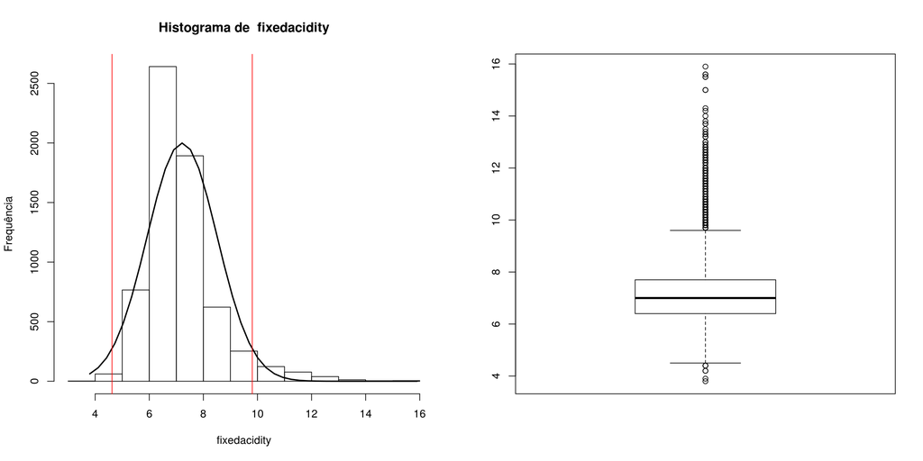

```r
hist.default <- function(x,
                         breaks = "Sturges",
                         freq = NULL,
                         include.lowest = TRUE,
                         normalcurve = TRUE,
                         right = TRUE,
                         density = NULL,
                         angle = 45,
                         col = NULL,
                         border = NULL,
                         main = paste("Histogram of", xname),
                         ylim = NULL,
                         xlab = xname,
                         ylab = NULL,
                         axes = TRUE,
                         plot = TRUE,
                         labels = FALSE,
                         warn.unused = TRUE,
                         ...)  {
  xname <- paste(deparse(substitute(x), 500), collapse = "\n")

  suppressWarnings(
    h <- graphics::hist.default(
      x = x,
      breaks = breaks,
      freq = freq,
      include.lowest = include.lowest,
      right = right,
      density = density,
      angle = angle,
      col = col,
      border = border,
      main = main,
      ylim = ylim,
      xlab = xlab,
      ylab = ylab,
      axes = axes,
      plot = plot,
      labels = labels,
      warn.unused = warn.unused,
      ...
    )
  )

  if (normalcurve == TRUE & plot == TRUE) {
    x <- x[!is.na(x)]
    xfit <- seq(min(x), max(x), length = 40)
    yfit <- dnorm(xfit, mean = mean(x), sd = sd(x))
    if (isTRUE(freq) | (is.null(freq) & is.null(density))) {
      yfit <- yfit * diff(h$mids[1:2]) * length(x)
    }
    lines(xfit, yfit, col = "black", lwd = 2)
  }

  if (plot == TRUE) {
    invisible(h)
  } else {
    h
  }
}

plotaGraficos <- function(fVinho, label){
par(mfrow = c(1,2))
hist(fVinho, main = paste("Histograma de ",label), xlab = label, ylab="Frequência")
abline(v = mean(fVinho) - 2 * sd(fVinho), col = "red")
abline(v = mean(fVinho) + 2 * sd(fVinho), col = "red")
boxplot(fVinho)
}

plotaGraficos(vinhos$fixedacidity, "fixedacidity")
```

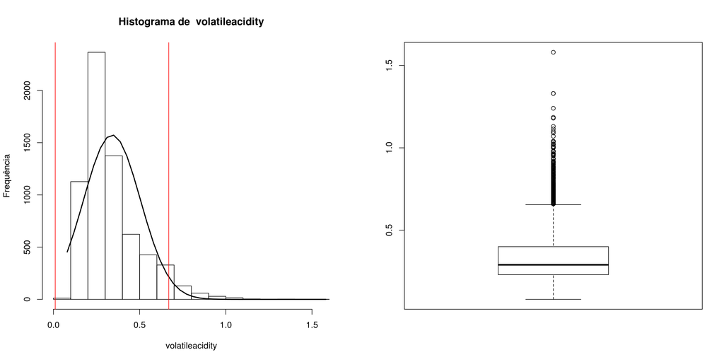

```r
plotaGraficos(vinhos$volatileacidity, "volatileacidity")
```

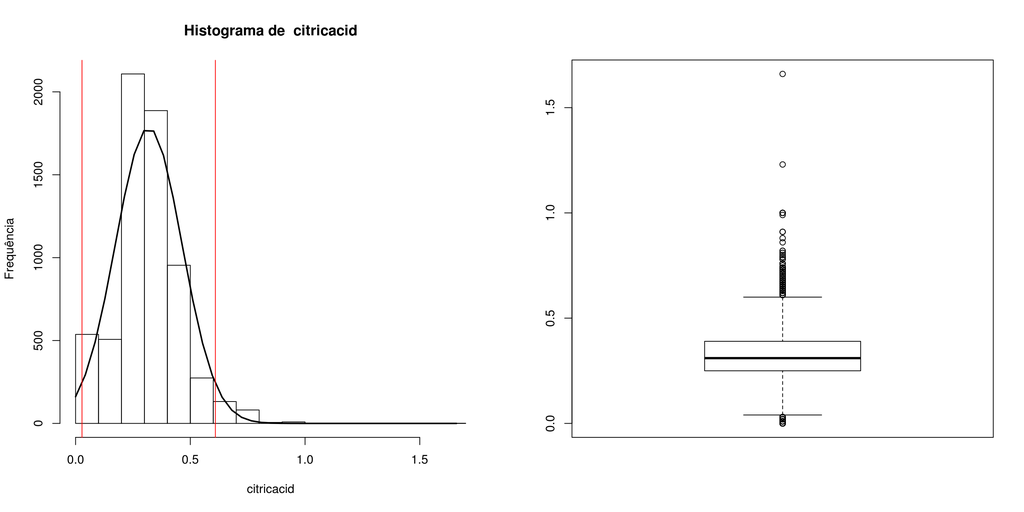

```r
plotaGraficos(vinhos$citricacid, "citricacid")
```

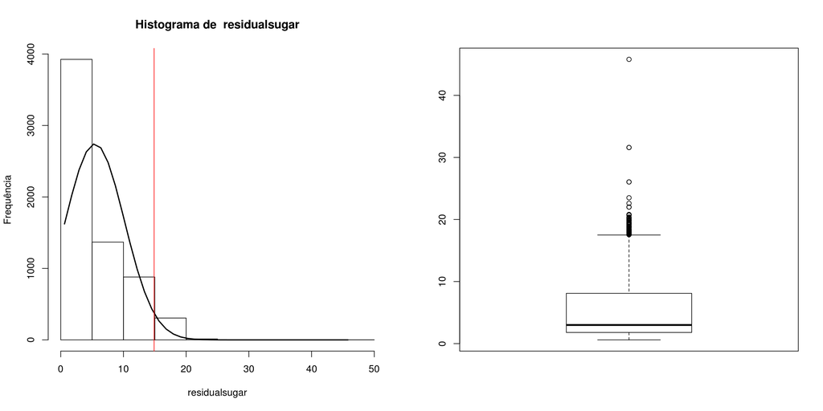

```r
plotaGraficos(vinhos$residualsugar, "residualsugar")
```

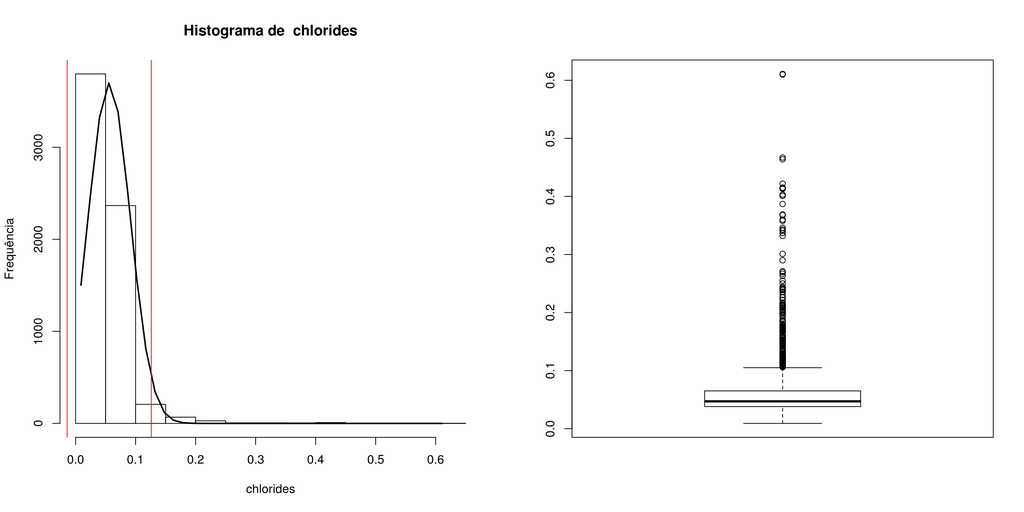

```r
plotaGraficos(vinhos$chlorides, "chlorides")
```

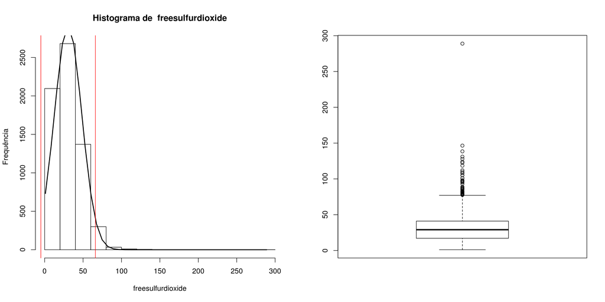

```r
plotaGraficos(vinhos$freesulfurdioxide, "freesulfurdioxide")
```

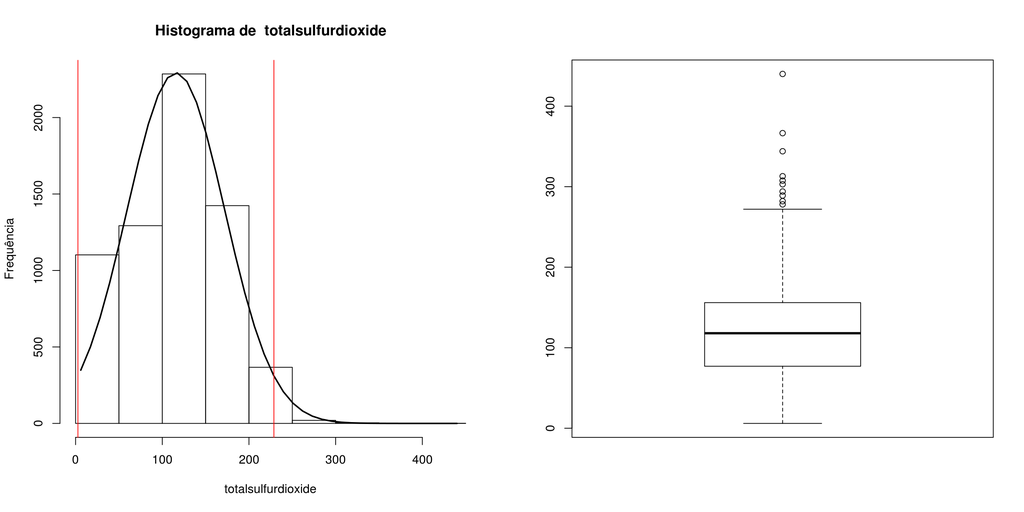

```r
plotaGraficos(vinhos$totalsulfurdioxide, "totalsulfurdioxide")
```

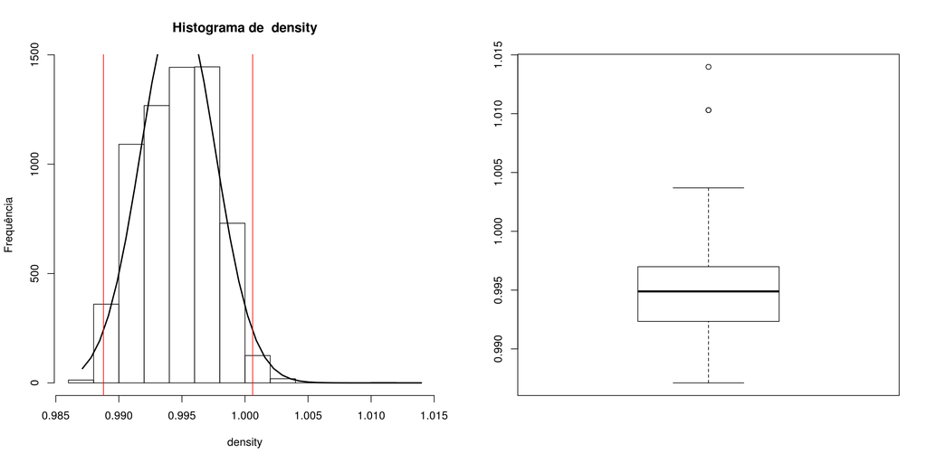

```r
plotaGraficos(vinhos$density, "density")
```

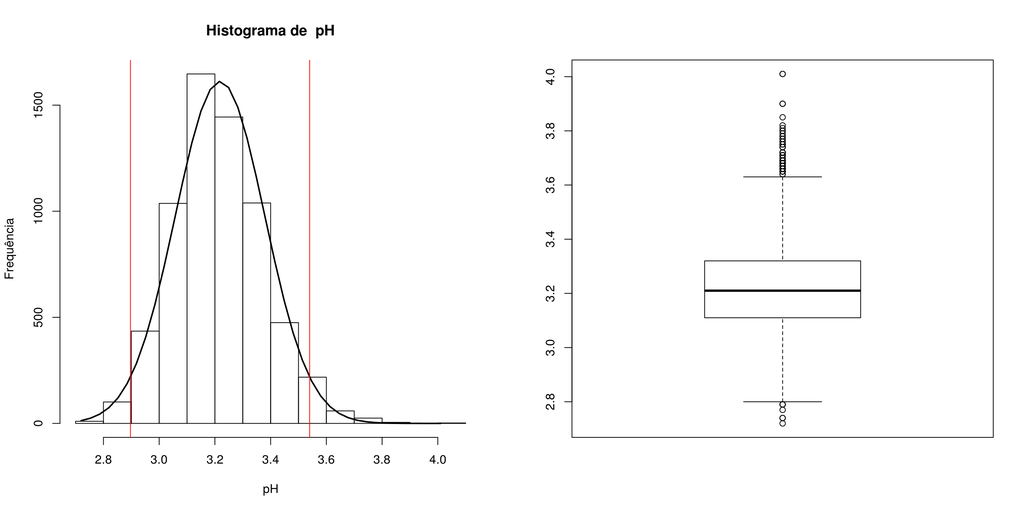

```r
plotaGraficos(vinhos$pH, "pH")
```

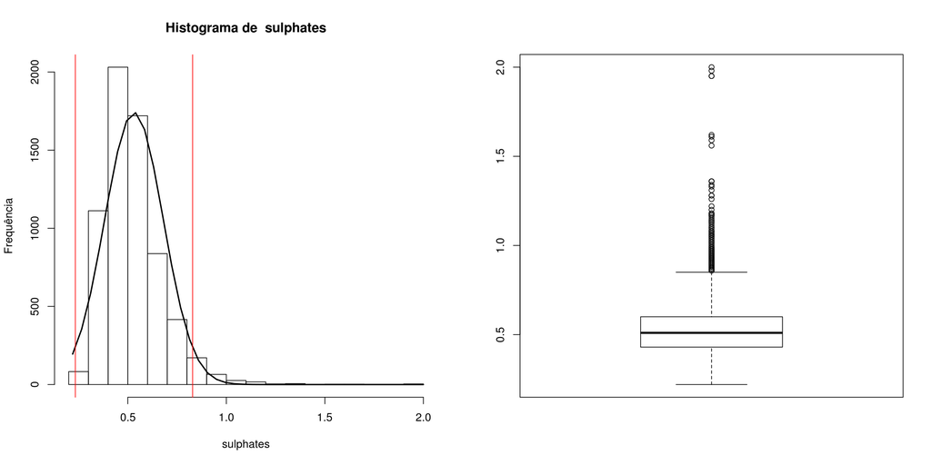

```r
plotaGraficos(vinhos$sulphates, "sulphates")
```

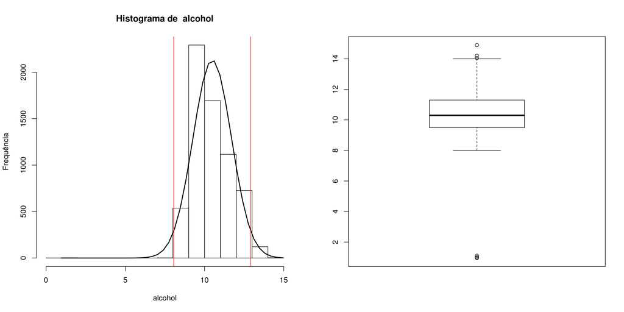

```r
plotaGraficos(vinhos$alcohol, "alcohol")
```

## 3.4 Removendo Outliers

Pelo boxplot é possível visualizar que há grupos distintos de vinhos dadas as características físico-químicas e a qualidade entre eles, mas também é possível notar que nas variáveis “residualsugar”, “freesilfurdioxide” e “totalsulfurdioxide” existem observações com valores muito distantes dos agrupamentos no gráfico e consideramos estas possíveis outliers, sendo assim, serão removidos para que não interfiram no resultado da análise e dos algoritmos

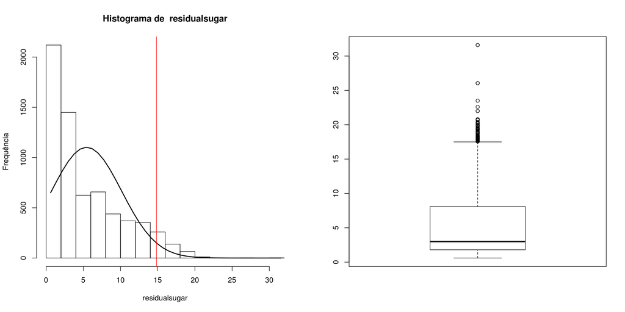

```r
vinhos <- vinhos%>%filter(residualsugar < 40)
vinhos <- vinhos%>%filter(freesulfurdioxide < 200)
vinhos <- vinhos%>%filter(totalsulfurdioxide < 400)

plotaGraficos(vinhos$residualsugar, "residualsugar")
```

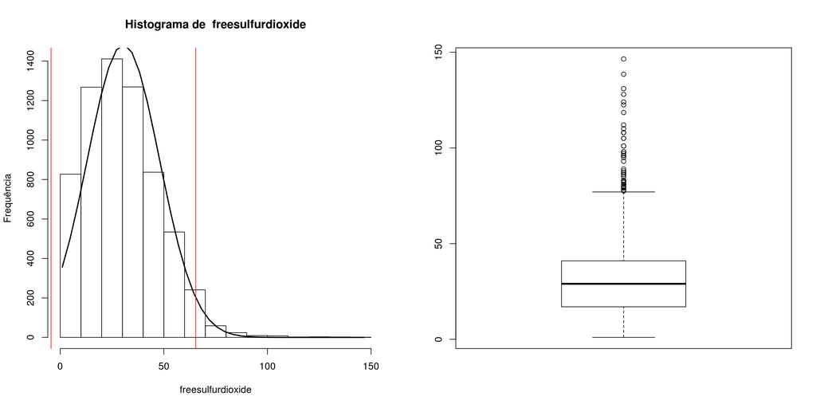

```r
plotaGraficos(vinhos$freesulfurdioxide, "freesulfurdioxide")
```

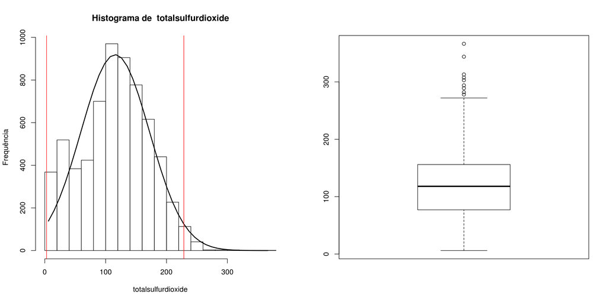

```r
plotaGraficos(vinhos$totalsulfurdioxide, "totalsulfurdioxide")
```

# 4 Correlação de variaveis

Gerando a correlação das variaveis, vai permitir o entendimento de quais carácteristicas estão mais relacionadas a nota de qualidade dadas aos vinho.

Vamos começar pela matriz de correlação.

## 4.1 Matriz de Correlação

Matriz de correlação mostra os valores de correlação de Pearson, que medem o grau de relação linear entre cada par de itens ou variáveis. Os valores de correlação podem cair entre -1 e +1.

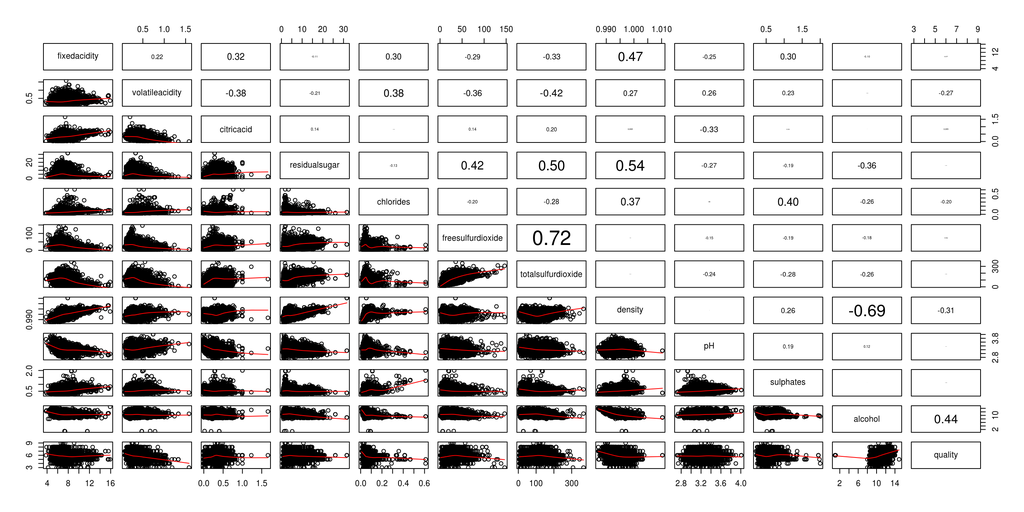

```r
matcor <- cor(vinhos%>%select(2:13))
panel.cor <- function(x, y, digits=2, prefix ="", cex.cor,
                      ...)  {
  usr <- par("usr")
  on.exit(par(usr))
  par(usr = c(0, 1, 0, 1))
  r <- cor(x, y , use = "pairwise.complete.obs")
  txt <- format(c(r, 0.123456789), digits = digits) [1]
  txt <- paste(prefix, txt, sep = "")
  if (missing(cex.cor))
    cex <- 0.8/strwidth(txt)
  text(0.5, 0.5, txt, cex = cex * abs(r))
}
pairs(vinhos%>%select(2:13), lower.panel=panel.smooth, upper.panel=panel.cor)
```

### 4.1.1 Conclusão

A Qualidade dos vinhos apresenta correlação com o teor alcoólico, densidade e acidez volátil, ainda que não seja um alto grau de correlação, porém, outras variáveis do dataset apresentam alta correlação entre si.

## 4.2 Estimando a qualidade do vinho

### 4.2.1 Regressão Linear

A regressão linear consiste em uma função que relaciona as variáveis que contém características do objeto de estudo a uma varíavel depente do mesmo objeto de estudo, gerando assim uma relação entre o resultado observado às suas possíveis explicações.

Usaremos o método stepwise no desenvolvimento do modelo, selecionando assim as variáveis que melhor estimem a qualidade do vinho

```r
vinhos_rl <- vinhos%>%select(2:13)
modelo_rl <- lm(vinhos$quality ~ vinhos_rl$fixedacidity + vinhos_rl$volatileacidity + vinhos_rl$citricacid + vinhos_rl$residualsugar + vinhos_rl$chlorides + vinhos_rl$freesulfurdioxide + vinhos_rl$totalsulfurdioxide + vinhos_rl$density + vinhos_rl$pH + vinhos_rl$sulphates + vinhos_rl$alcohol)
stepwise<-step(modelo_rl,direction="both")
```

```
## Start:  AIC=-3954.3
## vinhos$quality ~ vinhos_rl$fixedacidity + vinhos_rl$volatileacidity +
##     vinhos_rl$citricacid + vinhos_rl$residualsugar + vinhos_rl$chlorides +
##     vinhos_rl$freesulfurdioxide + vinhos_rl$totalsulfurdioxide +
##     vinhos_rl$density + vinhos_rl$pH + vinhos_rl$sulphates +
##     vinhos_rl$alcohol
##
##                                Df Sum of Sq    RSS     AIC
## - vinhos_rl$citricacid          1     0.963 3521.2 -3954.5
## - vinhos_rl$chlorides           1     0.977 3521.2 -3954.5
## <none>                                      3520.2 -3954.3
## - vinhos_rl$fixedacidity        1    25.207 3545.4 -3910.0
## - vinhos_rl$pH                  1    25.430 3545.6 -3909.5
## - vinhos_rl$density             1    31.458 3551.6 -3898.5
## - vinhos_rl$freesulfurdioxide   1    43.014 3563.2 -3877.4
## - vinhos_rl$totalsulfurdioxide  1    54.672 3574.9 -3856.2
## - vinhos_rl$residualsugar       1    63.273 3583.5 -3840.6
## - vinhos_rl$sulphates           1    69.150 3589.3 -3830.0
## - vinhos_rl$alcohol             1    91.819 3612.0 -3789.1
## - vinhos_rl$volatileacidity     1   139.605 3659.8 -3703.7
##
## Step:  AIC=-3954.52
## vinhos$quality ~ vinhos_rl$fixedacidity + vinhos_rl$volatileacidity +
##     vinhos_rl$residualsugar + vinhos_rl$chlorides + vinhos_rl$freesulfurdioxide +
##     vinhos_rl$totalsulfurdioxide + vinhos_rl$density + vinhos_rl$pH +
##     vinhos_rl$sulphates + vinhos_rl$alcohol
##
##                                Df Sum of Sq    RSS     AIC
## <none>                                      3521.2 -3954.5
## + vinhos_rl$citricacid          1     0.963 3520.2 -3954.3
## - vinhos_rl$chlorides           1     1.340 3522.5 -3954.1
## - vinhos_rl$fixedacidity        1    24.317 3545.5 -3911.8
## - vinhos_rl$pH                  1    26.135 3547.3 -3908.5
## - vinhos_rl$density             1    31.387 3552.5 -3898.9
## - vinhos_rl$freesulfurdioxide   1    43.318 3564.5 -3877.1
## - vinhos_rl$totalsulfurdioxide  1    58.696 3579.9 -3849.1
## - vinhos_rl$residualsugar       1    62.815 3584.0 -3841.7
## - vinhos_rl$sulphates           1    68.509 3589.7 -3831.4
## - vinhos_rl$alcohol             1    90.915 3612.1 -3791.0
## - vinhos_rl$volatileacidity     1   153.190 3674.3 -3679.9
```

```r
summary(stepwise)
```

```
##
## Call:
## lm(formula = vinhos$quality ~ vinhos_rl$fixedacidity + vinhos_rl$volatileacidity +
##     vinhos_rl$residualsugar + vinhos_rl$chlorides + vinhos_rl$freesulfurdioxide +
##     vinhos_rl$totalsulfurdioxide + vinhos_rl$density + vinhos_rl$pH +
##     vinhos_rl$sulphates + vinhos_rl$alcohol)
##
## Residuals:
##     Min      1Q  Median      3Q     Max
## -3.5625 -0.4657 -0.0423  0.4708  3.0081
##
## Coefficients:
##                                Estimate Std. Error t value Pr(>|t|)
## (Intercept)                   9.185e+01  1.181e+01   7.779 8.44e-15 ***
## vinhos_rl$fixedacidity        1.008e-01  1.507e-02   6.692 2.39e-11 ***
## vinhos_rl$volatileacidity    -1.194e+00  7.111e-02 -16.796  < 2e-16 ***
## vinhos_rl$residualsugar       5.449e-02  5.066e-03  10.755  < 2e-16 ***
## vinhos_rl$chlorides          -5.181e-01  3.299e-01  -1.571    0.116
## vinhos_rl$freesulfurdioxide   6.859e-03  7.680e-04   8.931  < 2e-16 ***
## vinhos_rl$totalsulfurdioxide -2.832e-03  2.724e-04 -10.396  < 2e-16 ***
## vinhos_rl$density            -9.163e+01  1.205e+01  -7.602 3.32e-14 ***
## vinhos_rl$pH                  6.225e-01  8.973e-02   6.937 4.38e-12 ***
## vinhos_rl$sulphates           8.525e-01  7.590e-02  11.232  < 2e-16 ***
## vinhos_rl$alcohol             2.081e-01  1.608e-02  12.939  < 2e-16 ***
## ---
## Signif. codes:  0 '***' 0.001 '**' 0.01 '*' 0.05 '.' 0.1 ' ' 1
##
## Residual standard error: 0.7369 on 6484 degrees of freedom
## Multiple R-squared:  0.288,  Adjusted R-squared:  0.2869
## F-statistic: 262.3 on 10 and 6484 DF,  p-value: < 2.2e-16
```

Através da sumarização do modelo podemos observar que a quantidade de sal presente nos vinhos não é relevante para a estimarmos a qualidade e será removida da modelo final

```r
modelo_rl_final <- lm(vinhos_rl$quality ~ vinhos_rl$fixedacidity + vinhos_rl$volatileacidity + vinhos_rl$citricacid + vinhos_rl$residualsugar + vinhos_rl$freesulfurdioxide + vinhos_rl$totalsulfurdioxide + vinhos_rl$density + vinhos_rl$pH + vinhos_rl$sulphates + vinhos_rl$alcohol)
pred <- predict(modelo_rl_final,interval = "prediction", level = 0.95)
fit <- pred[,1]
mse <- mean((vinhos_rl$quality  - fit)^2)
sqrt(mse)
```

```
## [1] 0.7362984
```